# A Markov Analysis of Country-Level Social Mobility, 1860-1916

Jared Walker

jaredwalker@pm.me

ChatGPT

# 1 Introduction

What follows is a revision of my thesis research project, *Do Poor Countries Catch Up to Rich Countries? Structural Change in the World Economy, 1816-1916*. It is a Markov analysis of country-level social mobility with inputs *upper class*, *middle class*, and *lower class* derived from frequency distributions. Histograms were plotted using national primary energy consumption weighted by population with a density overlay. Raw data were taken from the National Materiel Capabilities data set (version 6) hosted by the Correlates of War Project. Primary energy consumption was used as a proxy for industrial output or level of industrialization. Minima in the density overlay were interpreted as class boundaries. Bandwidth was methodologically determined. This approach produced three classes between 1860 and 1880 and four classes between 1881 and 1916. The fourth class in the second era was the result of non-industrial countries developing industrial capabilities and breaking into those markets. It can be seen as a bifurcation of the lower class and an adaptation of its role as the source of cheap labor in the evolving world economy. As the lower class became increasingly industrialized, primary energy consumption was no longer a distinguishing feature of class, and after 1916, this approach to operationalizing class structure was unreliable.

An evaluation of Markovian memory rejected independence in favor of first-order dependence, indicating strong state dependence–a country’s position at one time point strongly predicts its position at the next. The second order test failed to reject first order sufficiency, not because higher order dependence was absent, but because the high degree of persistence rendered the test uninformative. Over the long interval, Pearson and likelihood-ratio chi-square tests strongly rejected independence, implying substantial long-run persistence in countries’ hierarchical positions. The Markov chain failed the test of approximate ergodicity. That is to say, the long-term distribution of countries in the upper, middle, and lower classes was not random. A country’s starting position had a lasting effect for the period of examination.

These findings support the contention that economic development, while reducing poverty and improving living conditions, does not change the relative differences of countries in the global economic hierarchy. In this sense, findings undermine the central claim of economic convergence, namely that poor countries are catching up to rich countries.

```r
# Preferences
options(scipen = 999,
        digits = 2)
# Package Dependencies
library(dplyr)
library(tidyr)
library(ggplot2)
library(MASS)
library(parallel)
library(readxl)
library(knitr)

# Data Import and Recoding
df <- read_excel("Class Assignments.xlsx") %>%
  dplyr::select(stateabb, year, class) %>%
  dplyr::mutate(class = dplyr::recode(class,
                                      "core"          = "upper_class",
                                      "semiperiphery" = "middle_class",
                                      "periphery_1"   = "lower_class_1",
                                      "periphery_2"   = "lower_class_2"))
```

# 2 Transition Sequence Construction

```r
build_transitions <- function(data,
                                       snapshot_years,
                                       step,
                                       full_levels) {
  df_snap <- data %>%
    dplyr::filter(year %in% snapshot_years) %>%
    dplyr::mutate(class = factor(class, levels = full_levels))
  df_balanced <- df_snap %>%
    arrange(stateabb, year) %>%
    group_by(stateabb) %>%
    mutate(n_obs = n()) %>%
    ungroup()
  message("Balanced-panel countries for snapshots {",
          paste(snapshot_years, collapse = ", "),
          "}: ", paste("n =",
          length(unique(df_balanced$stateabb))))
  df_trans <- df_balanced %>%
    dplyr::arrange(stateabb, year) %>%
    dplyr::group_by(stateabb) %>%
    dplyr::mutate(
      class_prev = dplyr::lag(class),
      year_prev  = dplyr::lag(year)) %>%
    dplyr::ungroup() %>%
    dplyr::filter(
      !is.na(class_prev),
      (year - year_prev) %in% step) %>%
    dplyr::mutate(
      step_id = factor(paste0(year_prev, "→", year)))
  df_trans
}

# ERA 1: 1860-1880
# 3-class system: upper_class, middle_class, lower_class_1
# Snapshots: 1860, 1865, 1870, 1875, 1880 (5-year steps)

# ---- Subset data ----
era1_years <- 1860:1880
df1 <- df %>% dplyr::filter(year %in% era1_years)

levels_era1 <- c("upper_class", "middle_class", "lower_class_1")

snap1 <- c(1860, 1865, 1870, 1875, 1880)
step1 <- 5

# ---- Build transitions ----
trans1 <- build_transitions(
  data           = df1,
  snapshot_years = snap1,
  step           = step1,
  full_levels    = levels_era1)

# ERA 2: (1881-1916)
# 3-class system: upper_class, middle_class, lower_class_2, lower_class_1
# Snapshots: 1881, 1886, 1891, 1896, 1901, 1906, 1911, 1916 (5-year steps)

# ---- Subset data ----
era2_years <- 1881:1916
df2 <- df %>% dplyr::filter(year %in% era2_years)

levels_era2 <- c("upper_class", "middle_class", "lower_class_2", "lower_class_1")

snap2 <- c(1881, 1886, 1891, 1896, 1901, 1906, 1911, 1916)
step2 <- 5

# ---- Build transitions ----
trans2 <- build_transitions(
  data           = df2,
  snapshot_years = snap2,
  step           = step2,
  full_levels    = levels_era2)

# Dataset Overview
era_summary <- tibble::tibble(
  Era = c("ERA 1 (1860-1880)", "ERA 2 (1881-1916)"),
  Snapshots = c(
  paste(snap1, collapse = ", "),
  paste(snap2, collapse = ", ")),
  Transitions = c(
  nrow(trans1),
  nrow(trans2)))

cat('Balanced-panel snapshot coverage and transition counts')
era_summary_ordered <- era_summary %>%
  dplyr::select(Era, Transitions, Snapshots)

kable(era_summary_ordered,
      align = c("l", "l", "r"))
```

```
Balanced-panel snapshot coverage and transition counts
```

| Era | Transitions | Snapshots |
| --- | --- | --- |
| ERA 1 (1860-1880) | 138 | 1860, 1865, 1870, 1875, 1880 |
| ERA 2 (1881-1916) | 274 | 1881, 1886, 1891, 1896, 1901, 1906, 1911, 1916 |

# 3 Sample Attrition Diagnostics

```r
attrition_diagnostic <- function(data,
                                 snapshot_years,
                                 balanced_df,
                                 full_levels) {
  kept_states <- unique(balanced_df$stateabb)
  year0 <- min(snapshot_years)
  all_year0 <- data %>%
    dplyr::filter(year == year0) %>%
    dplyr::mutate(class = factor(class, levels = full_levels)) %>%
    dplyr::count(class, name = "n") %>%
    dplyr::mutate(group = "All")
  kept_year0 <- data %>%
    dplyr::filter(year == year0, stateabb %in% kept_states) %>%
    dplyr::mutate(class = factor(class, levels = full_levels)) %>%
    dplyr::count(class, name = "n") %>%
    dplyr::mutate(group = "Balanced")
  df_comp <- dplyr::bind_rows(all_year0, kept_year0)
  tab <- xtabs(n ~ group + class, data = df_comp)
  chisq <- suppressWarnings(chisq.test(tab))
  list(counts = df_comp,
       table = tab,
       chisq = chisq)
}

interpret_attrition <- function(chisq_obj, alpha = 0.05) {
  p <- chisq_obj$p.value
  if (p < alpha) {
    paste0("Reject equality of baseline class distributions (p < ", alpha,
           "). Evidence of selective attrition.")
  } else {
    paste0("Fail to reject equality of baseline class distributions (p ≥ ", alpha,
           "). No evidence of selective attrition.")
  }
}

print_chisq_compact <- function(chisq_obj) {
  cat("X^2 =", round(chisq_obj$statistic, 3),
      " df =", chisq_obj$parameter,
      " p =", signif(chisq_obj$p.value, 4), "\n")
}
```

## 3.1 ERA 1 1860-1880

```r
# ---- Attrition diagnostic (ERA 1) ----
df1_snap <- df1 %>% dplyr::filter(year %in% snap1)
df1_balanced <- df1_snap %>%
  dplyr::group_by(stateabb) %>%
  dplyr::filter(dplyr::n() == length(snap1)) %>%
  dplyr::ungroup()

attr1 <- attrition_diagnostic(df1, snap1, df1_balanced, levels_era1)

cat("\n----------------------------------------\n")
cat("ERA 1 Attrition diagnostic\n")
cat("----------------------------------------\n")

cat("\nTest statistics:\n")
print_chisq_compact(attr1$chisq)

cat("\nInterpretation:\n")
cat(interpret_attrition(attr1$chisq), "\n")

cat("\nObserved counts:\n")
print(attr1$counts)
```

```
----------------------------------------
ERA 1 Attrition diagnostic
----------------------------------------

Test statistics:
X^2 = 0.097  df = 2  p = 0.95

Interpretation:
Fail to reject equality of baseline class distributions (p ≥ 0.05). No evidence of selective attrition.

Observed counts:
# A tibble: 6 × 3
  class             n group
  <fct>         <int> <chr>
1 upper_class       8 All
2 middle_class     16 All
3 lower_class_1    13 All
4 upper_class       6 Balanced
5 middle_class     14 Balanced
6 lower_class_1    12 Balanced
```

## 3.2 ERA 2 1881-1916

```r
# ---- Attrition diagnostic (ERA 2) ----
df2_snap <- df2 %>% dplyr::filter(year %in% snap2)
df2_balanced <- df2_snap %>%
  dplyr::group_by(stateabb) %>%
  dplyr::filter(dplyr::n() == length(snap2)) %>%
  dplyr::ungroup()

attr2 <- attrition_diagnostic(df2, snap2, df2_balanced, levels_era2)

cat("\n----------------------------------------\n")
cat("ERA 2 Attrition diagnostic\n")
cat("----------------------------------------\n")

cat("\nTest statistics:\n")
print_chisq_compact(attr2$chisq)

cat("\nInterpretation:\n")
cat(interpret_attrition(attr2$chisq), "\n")

cat("\nObserved counts:\n")
print(attr2$counts)
```

```
----------------------------------------
ERA 2 Attrition diagnostic
----------------------------------------

Test statistics:
X^2 = 0.5  df = 3  p = 0.92

Interpretation:
Fail to reject equality of baseline class distributions (p ≥ 0.05). No evidence of selective attrition.

Observed counts:
# A tibble: 8 × 3
  class             n group
  <fct>         <int> <chr>
1 upper_class       7 All
2 middle_class     16 All
3 lower_class_2     1 All
4 lower_class_1    13 All
5 upper_class       7 Balanced
6 middle_class     16 Balanced
7 lower_class_2     1 Balanced
8 lower_class_1     9 Balanced
```

# 4 5-Year Step Transition Matrices

```r
# ---- Heatmap Function (Probabilities Only) ----
plot_prob_heatmap <- function(P, title, subtitle = NULL) {
  df_plot <- as.data.frame(as.table(P))
  colnames(df_plot) <- c("origin", "dest", "prob")
  df_plot$origin <- factor(df_plot$origin, levels = rev(rownames(P)))
  df_plot$dest   <- factor(df_plot$dest,   levels = colnames(P))
  ggplot2::ggplot(df_plot, ggplot2::aes(x = dest, y = origin, fill = prob)) +
    ggplot2::geom_tile(color = "grey70", linewidth = 0.3) +
    ggplot2::geom_text(ggplot2::aes(label = sprintf("%.2f", prob)), size = 4) +
    ggplot2::scale_fill_gradient(low = "white", high = "steelblue") +
    ggplot2::scale_x_discrete(position = "top") +
    ggplot2::labs(
      title = title,
      subtitle = subtitle,
      x = "Destination class",
      y = "Origin class",
      fill = "Prob"
    ) +
    ggplot2::theme_minimal(base_size = 13) +
    ggplot2::theme(
      axis.text.x.top = ggplot2::element_text(margin = ggplot2::margin(b = 10)),
      axis.title.x.top = ggplot2::element_text(margin = ggplot2::margin(b = 20)),
      axis.title.y = ggplot2::element_text(margin = ggplot2::margin(r = 20)),
      axis.ticks = ggplot2::element_line(color = "black", linewidth = 0.4),
      panel.grid = ggplot2::element_blank()
    ) +
    ggplot2::coord_fixed(ratio = 0.8)
}

# ERA 1 COMPUTATIONS (5-Year)
# Counts
C1 <- xtabs(~ class_prev + class, data = trans1)
C1 <- C1[levels_era1, levels_era1, drop = FALSE]
C1_df <- as.data.frame.matrix(C1)

# Probabilities
P1 <- prop.table(C1, margin = 1)
P1_df <- as.data.frame.matrix(round(P1, 3))

# Plot
p1_probs <- plot_prob_heatmap(P1, "ERA 1 Probabilities (1860-1880)", "5-year steps")

# ERA 2 COMPUTATIONS (5-Year)
# Counts
C2 <- xtabs(~ class_prev + class, data = trans2)
C2 <- C2[levels_era2, levels_era2, drop = FALSE]
C2_df <- as.data.frame.matrix(C2)

# Probabilities
P2 <- prop.table(C2, margin = 1)
P2_df <- as.data.frame.matrix(round(P2, 3))

# Plot
p2_probs <- plot_prob_heatmap(P2, "ERA 2 Probabilities (1881-1916)", "5-year steps")
```

## 4.1 ERA 1 1860-1880

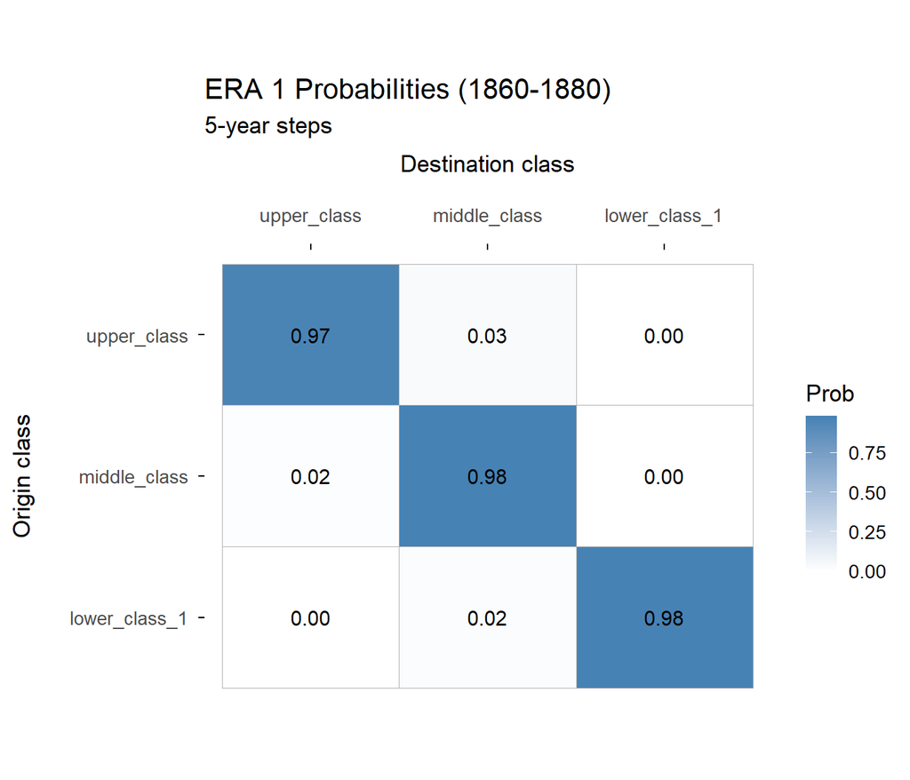

```
Transition Counts
```

Era 1 Counts

|  | upper_class | middle_class | lower_class_1 |
| --- | --- | --- | --- |
| upper_class | 28 | 1 | 0 |
| middle_class | 1 | 57 | 0 |
| lower_class_1 | 0 | 1 | 50 |

```r
# Print Count Matrix
cat("Transition Counts")
knitr::kable(C1_df, caption = "Era 1 Counts")

# Print Probability Matrix
#cat("Transition Probabilities")
#knitr::kable(P1_df, caption = "Era 1 Probabilities")

# Plot Probability Heatmap
print(p1_probs)
```

## 4.2 ERA 2 1881-1916

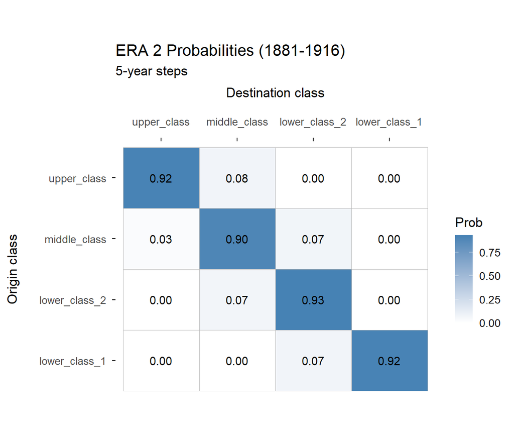

```
<strong>Transition Counts</strong>
```

Era 2 Counts

|  | upper_class | middle_class | lower_class_2 | lower_class_1 |
| --- | --- | --- | --- | --- |
| upper_class | 36 | 3 | 0 | 0 |
| middle_class | 3 | 100 | 8 | 0 |
| lower_class_2 | 0 | 3 | 41 | 0 |
| lower_class_1 | 0 | 0 | 6 | 74 |

```r
# Print Count Matrix
cat("<strong>Transition Counts</strong>")
knitr::kable(C2_df, caption = "Era 2 Counts")

# Print Probability Matrix
#cat("<br><strong>Transition Probabilities</strong>")
#knitr::kable(P2_df, caption = "Era 2 Probabilities")

# Plot Probability Heatmap
print(p2_probs)
```